# AQM Week 11 – Nested Data I

[output not shown]

Unbalanced Panel: n = 15, T = 4-15, N = 139

Residuals: Min. 1st Qu. Median 3rd Qu. Max. -26.5698 -3.3365 0.7488 4.0599 20.5531

Coefficients: Estimate Std. Error t-value Pr(>|t|)  
satislfe_survey_mean 18.7915 5.5556 3.3825 0.0009638 *** — Signif. codes: 0 ‘**’ 0.001 ‘**’ 0.01 ‘’ 0.05 ‘.’ 0.1 ‘ ’ 1

Total Sum of Squares: 6839.5 Residual Sum of Squares: 6257.5 R-Squared: 0.085101 Adj. R-Squared: -0.026472 F-statistic: 11.4411 on 1 and 123 DF, p-value: 0.00096383

````
```r
```r
summary(fe_1)
````

Call: lm(formula = vote_share_cab ~ satislfe_survey_mean + as.factor(country), data = dta)

Residuals: Min 1Q Median 3Q Max -26.5698 -3.3365 0.7488 4.0599 20.5531

Coefficients: Estimate Std. Error t value Pr(>|t|)  
(Intercept) -4.1445 17.3984 -0.238 0.812112  
satislfe_survey_mean 18.7915 5.5556 3.382 0.000964 as.factor(country)BEL -4.9655 3.5399 -1.403 0.163220  
as.factor(country)DEU -2.9294 3.6301 -0.807 0.421237  
as.factor(country)DNK -25.9045 4.2882 -6.041 1.68e-08 as.factor(country)ESP -12.4643 3.9014 -3.195 0.001778 ** as.factor(country)FIN -0.3649 4.6387 -0.079 0.937433  
as.factor(country)FRA -15.7479 3.9968 -3.940 0.000136 *as.factor(country)GBR -18.0236 3.7206 -4.844 3.74e-06* as.factor(country)GRC -4.0953 4.7534 -0.862 0.390613  
as.factor(country)IRL -14.2652 3.6413 -3.918 0.000147 as.factor(country)ITA -4.0091 4.2554 -0.942 0.347980  
as.factor(country)LUX -4.2656 3.9385 -1.083 0.280907  
as.factor(country)NLD -16.5458 3.9249 -4.216 4.78e-05 as.factor(country)PRT -3.6596 4.7765 -0.766 0.445044  
as.factor(country)SWE -19.3069 4.6118 -4.186 5.35e-05 *** — Signif. codes: 0 ‘**’ 0.001 ‘**’ 0.01 ‘’ 0.05 ‘.’ 0.1 ‘ ’ 1

Residual standard error: 7.133 on 123 degrees of freedom Multiple R-squared: 0.4973, Adjusted R-squared: 0.436 F-statistic: 8.113 on 15 and 123 DF, p-value: 1.679e-12

[output not shown]

Call: lm(formula = vote_share_cab ~ satislfe_survey_mean + as.factor(dta$year) + as.factor(dta$country), data = dta)

Residuals: Min 1Q Median 3Q Max -18.706 -2.384 0.000 2.998 16.267

Coefficients: Estimate Std. Error t value Pr(>|t|)  
(Intercept) -28.422 21.550 -1.319 0.190868  
satislfe_survey_mean 23.277 6.744 3.452 0.000883 as.factor(dta$year)1974 17.376 8.051 2.158 0.033832 * as.factor(dta$year)1975 -2.300 9.568 -0.240 0.810632  
as.factor(dta$year)1976 13.916 8.764 1.588 0.116159 as.factor(dta$year)1977 10.132 7.836 1.293 0.199644  
as.factor(dta$year)1978 7.845 8.841 0.887 0.377457 as.factor(dta$year)1979 15.994 7.814 2.047 0.043886  
as.factor(dta$year)1980 16.637 10.084 1.650 0.102804 as.factor(dta$year)1981 11.353 7.621 1.490 0.140136  
as.factor(dta$year)1982 9.686 8.324 1.164 0.247988 as.factor(dta$year)1983 19.800 8.243 2.402 0.018560 *  
as.factor(dta$year)1984 15.034 8.459 1.777 0.079235 . as.factor(dta$year)1985 12.587 8.853 1.422 0.158894  
as.factor(dta$year)1986 14.395 8.283 1.738 0.085977 . as.factor(dta$year)1987 12.513 7.516 1.665 0.099740 .  
as.factor(dta$year)1988 9.391 8.511 1.103 0.273085 as.factor(dta$year)1989 12.756 7.890 1.617 0.109763  
as.factor(dta$year)1990 10.808 8.507 1.270 0.207502 as.factor(dta$year)1991 16.207 8.921 1.817 0.072918 .  
as.factor(dta$year)1992 14.106 8.310 1.697 0.093404 . as.factor(dta$year)1993 6.628 8.332 0.796 0.428601  
as.factor(dta$year)1994 13.128 7.845 1.673 0.098067 . as.factor(dta$year)1995 11.993 8.353 1.436 0.154896  
as.factor(dta$year)1996 13.466 8.889 1.515 0.133614 as.factor(dta$year)1997 6.247 8.266 0.756 0.451941  
as.factor(dta$year)1998 13.457 7.840 1.716 0.089872 . as.factor(dta$year)1999 14.511 7.855 1.847 0.068297 .  
as.factor(dta$year)2000 11.505 9.075 1.268 0.208460 as.factor(dta$year)2001 10.043 8.114 1.238 0.219377  
as.factor(dta$year)2002 8.987 7.665 1.172 0.244415 as.factor(dta$year)2003 11.397 8.285 1.376 0.172684  
as.factor(dta$year)2004 9.556 8.362 1.143 0.256456 as.factor(dta$year)2005 5.740 7.931 0.724 0.471288  
as.factor(dta$year)2006 5.110 8.076 0.633 0.528670 as.factor(dta$year)2007 7.857 7.727 1.017 0.312219  
as.factor(dta$year)2008 12.285 8.343 1.472 0.144733 as.factor(dta$year)2009 14.633 7.962 1.838 0.069694 .  
as.factor(dta$year)2010 2.023 8.086 0.250 0.803072 as.factor(dta$year)2011 -2.143 7.727 -0.277 0.782207  
as.factor(dta$year)2012 7.787 8.270 0.942 0.349149 as.factor(dta$year)2013 9.693 8.295 1.169 0.245988  
as.factor(dta$year)2014 11.236 8.940 1.257 0.212381 as.factor(dta$country)BEL -6.146 3.853 -1.595 0.114542  
as.factor(dta$country)DEU -4.945 4.000 -1.236 0.219819 as.factor(dta$country)DNK -26.270 5.079 -5.172 1.61e-06 as.factor(dta$country)ESP -11.341 4.437 -2.556 0.012428 * as.factor(dta$country)FIN 1.702 5.034 0.338 0.736101  
as.factor(dta$country)FRA -13.166 4.581 -2.874 0.005159 ** as.factor(dta$country)GBR -20.140 4.225 -4.767 8.00e-06 **as.factor(dta$country)GRC -2.053 5.628 -0.365 0.716261 as.factor(dta$country)IRL -13.351 4.074 -3.278 0.001537** as.factor(dta$country)ITA -5.090 4.602 -1.106 0.271927 as.factor(dta$country)LUX -8.416 4.344 -1.937 0.056159 .  
as.factor(dta$country)NLD -17.457 4.400 -3.967 0.000155 *** as.factor(dta$country)PRT -1.255 5.315 -0.236 0.813944  
as.factor(dta$country)SWE -18.345 4.951 -3.705 0.000382 *** — Signif. codes: 0 ‘**’ 0.001 ‘**’ 0.01 ‘’ 0.05 ‘.’ 0.1 ‘ ’ 1

Residual standard error: 6.766 on 82 degrees of freedom Multiple R-squared: 0.6985, Adjusted R-squared: 0.4926 F-statistic: 3.392 on 56 and 82 DF, p-value: 2.595e-07

[output not shown]

Call: lm(formula = vote_share_cab ~ satislfe_survey_mean + parties_ingov + seatshare_cabinet + cab_ideol_sd + ENEP_tmin1 + as.factor(dta$country), data = dta)

Residuals: Min 1Q Median 3Q Max -20.8107 -3.0005 0.1983 3.9368 17.5065

Coefficients: Estimate Std. Error t value Pr(>|t|)  
(Intercept) -4.2039 17.6612 -0.238 0.812268  
satislfe_survey_mean 15.6622 5.2606 2.977 0.003525 ** parties_ingov 2.1246 0.9782 2.172 0.031847 *  
seatshare_cabinet 18.3195 7.6047 2.409 0.017531 *  
cab_ideol_sd 0.3324 1.1845 0.281 0.779499  
ENEP_tmin1 -1.6893 0.7445 -2.269 0.025065 *  
as.factor(dta$country)BEL -2.2272 5.0609 -0.440 0.660678 as.factor(dta$country)DEU -3.1519 3.6448 -0.865 0.388911  
as.factor(dta$country)DNK -17.8473 4.4945 -3.971 0.000123 *** as.factor(dta$country)ESP -8.7176 3.9928 -2.183 0.030974 *  
as.factor(dta$country)FIN -1.3644 4.7591 -0.287 0.774843 as.factor(dta$country)FRA -11.6046 4.0980 -2.832 0.005438 ** as.factor(dta$country)GBR -14.9601 3.8291 -3.907 0.000156 *** as.factor(dta$country)GRC -4.3843 4.7617 -0.921 0.359052  
as.factor(dta$country)IRL -12.3215 3.4521 -3.569 0.000517 *** as.factor(dta$country)ITA -2.5790 4.5334 -0.569 0.570500  
as.factor(dta$country)LUX -2.9460 3.6728 -0.802 0.424086 as.factor(dta$country)NLD -12.2711 3.8533 -3.185 0.001851 ** as.factor(dta$country)PRT -1.4661 4.7683 -0.307 0.759030 as.factor(dta$country)SWE -14.2478 4.6033 -3.095 0.002453 ** — Signif. codes: 0 ‘**’ 0.001 ‘**’ 0.01 ‘’ 0.05 ‘.’ 0.1 ‘ ’ 1

Residual standard error: 6.561 on 119 degrees of freedom Multiple R-squared: 0.5885, Adjusted R-squared: 0.5228 F-statistic: 8.958 on 19 and 119 DF, p-value: 2.684e-15

[output not shown]

Call: lm(formula = vote_share_cab ~ satislfe_survey_mean + as.factor(country), data = dta)

Residuals: Min 1Q Median 3Q Max -26.5698 -3.3365 0.7488 4.0599 20.5531

Coefficients: Estimate Std. Error t value Pr(>|t|)  
(Intercept) -4.1445 17.3984 -0.238 0.812112  
satislfe_survey_mean 18.7915 5.5556 3.382 0.000964 as.factor(country)BEL -4.9655 3.5399 -1.403 0.163220  
as.factor(country)DEU -2.9294 3.6301 -0.807 0.421237  
as.factor(country)DNK -25.9045 4.2882 -6.041 1.68e-08 as.factor(country)ESP -12.4643 3.9014 -3.195 0.001778 ** as.factor(country)FIN -0.3649 4.6387 -0.079 0.937433  
as.factor(country)FRA -15.7479 3.9968 -3.940 0.000136 *as.factor(country)GBR -18.0236 3.7206 -4.844 3.74e-06* as.factor(country)GRC -4.0953 4.7534 -0.862 0.390613  
as.factor(country)IRL -14.2652 3.6413 -3.918 0.000147 as.factor(country)ITA -4.0091 4.2554 -0.942 0.347980  
as.factor(country)LUX -4.2656 3.9385 -1.083 0.280907  
as.factor(country)NLD -16.5458 3.9249 -4.216 4.78e-05 as.factor(country)PRT -3.6596 4.7765 -0.766 0.445044  
as.factor(country)SWE -19.3069 4.6118 -4.186 5.35e-05 *** — Signif. codes: 0 ‘**’ 0.001 ‘**’ 0.01 ‘’ 0.05 ‘.’ 0.1 ‘ ’ 1

Residual standard error: 7.133 on 123 degrees of freedom Multiple R-squared: 0.4973, Adjusted R-squared: 0.436 F-statistic: 8.113 on 15 and 123 DF, p-value: 1.679e-12

[output not shown]

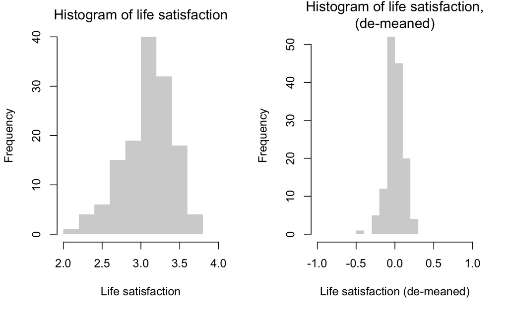

````r
```r

sd(dta$satislfe_survey_mean)
````

[1] 0.3119164

````
```r
```r
sd(dta$demeaned_satis)
````

[1] 0.1092898

[output not shown]

[output not shown]